# Table of Contents

```python
import requests
import pandas as pd
import datetime
from bs4 import BeautifulSoup
```

## Bookdepositort Dataset

The link to code is shared below under "Linked Sources".

```python
# Import Bookdepository CSV
books = pd.read_csv("/Users/nat/Downloads/NaturalHistory-Bookdepository-2021.csv", dtype=str)
books.head(5)
```

|  | Unnamed: 0 | authors | titles | date | year |
| --- | --- | --- | --- | --- | --- |
| 0 | 17 | Merlin Sheldrake | Entangled Life | 02 Sep 2021 | 2021 |
| 1 | 35 | Jeremy Clarkson | Diddly Squat | 11 Nov 2021 | 2021 |
| 2 | 38 | Lia Leendertz | The Almanac | 02 Sep 2021 | 2021 |
| 3 | 43 | Sosuke Natsukawa | The Cat Who Saved Books | 16 Sep 2021 | 2021 |
| 4 | 60 | James Stewart | Dinosaur Therapy | 24 Aug 2021 | 2021 |

```python
# Fill in the NaN values to prevent future errors
for i in range(len(books['authors'])):
    author = books['authors'][i]
    boolean = pd.isna(author) # true or false

    if boolean == False:
        books['authors'][i] = books['authors'][i]
    else:
        books['authors'][i] = "No Author"

# Before filling the NaN values the below cell was empty
# books['authors'][854]
```

## Virtual International Authority File (VIAF) Dataset

**What is VIAF?** You can read more about VIAF [here](https://en.wikipedia.org/wiki/Virtual_International_Authority_File). It is a database that combines information from multiple authorities inclusing libraries.

**Why I use it?** Each author VIAF page has information about the author, including their gender. Check Urusla K. Le Guin's page [here](http://viaf.org/viaf/101734435/#Le_Guin,_Ursula_K.,_1929-2018) for example.

**Where to download? Size.** This is the dataset downloaded from [here](http://viaf.org/viaf/data/). The txt.gz file is 1,33 GB and when its unzipped the csv file is 9,37 GB. In another notebook I simplified this file by getting the rows that only contained "en.wikipedia.org" as a string. Because most authors have a wikipedia page.

The link to code is shared below under "Linked Sources".

This method ofcourse has limitations such as eliminating authors that doesnt have a wikipedi page or who has it but is in another language. So this can be improved. But at least this way I deacresed the file size (from ~ 9 GB) to ~ 94 MB.

```python
# Import VIAF CSV
viaf_db = pd.read_csv("/Users/nat/Downloads/viaf-simple.csv", dtype=str)

# Get the name of the person from the Wiki links
viaf_db['Name'] = viaf_db['info'].str.split('wiki/').str[1]
viaf_db['Name'] = viaf_db['Name'].str.split('_\(').str[0]
viaf_db['Name'] = viaf_db['Name'].str.replace('_',' ')
viaf_db.drop('Unnamed: 0', axis=1, inplace=True)

viaf_db.head(5)
```

|  | viaf | info | Name |
| --- | --- | --- | --- |
| 0 | http://viaf.org/viaf/100177876 | Wikipedia@https://en.wikipedia.org/wiki/Guilla... | Guillaume Caoursin |
| 1 | http://viaf.org/viaf/100208187 | Wikipedia@https://en.wikipedia.org/wiki/César-... | César-Pierre Richelet |
| 2 | http://viaf.org/viaf/100232568 | Wikipedia@https://en.wikipedia.org/wiki/Paul_B... | Paul B. Weisz |
| 3 | http://viaf.org/viaf/100232612 | Wikipedia@https://en.wikipedia.org/wiki/Paul_B... | Paul B. Thompson |
| 4 | http://viaf.org/viaf/100319661 | Wikipedia@https://en.wikipedia.org/wiki/John_G... | John Gosling |

### Check VIAF links by using the Bookdepository author names

So VIAF file may contain many people and not necesseraly only authors. But we already have our author names from bookdepository. All we need to do is to cross check and link the book depository authors to their VIAF pages (if it exists).

```python
links = []
author_with_viaf = []
books_with_viaf = []

names_to_predict = []
author_without_viaf = []
books_without_viaf = []

for i in range(len(books['authors'])):

    # Find whether the name in bookdeposit dataset exists in VIAF dataset
    name = books['authors'][i]
    #print(i, name)
    boolean_finding = viaf_db['Name'].str.contains(name, case=False).any() # True or False

    # If its true get the viaf link
    if boolean_finding == True:

        df2 = viaf_db[(viaf_db['Name'].str.contains(name, case=False))]
        viaf_link = df2['viaf'].loc[df2.index[0]]
        links.append(viaf_link)

        author_with_viaf.append(books['authors'][i])
        books_with_viaf.append(books['titles'][i])

    else:
        names_to_predict.append(name)
        author_without_viaf.append(books['authors'][i])
        books_without_viaf.append(books['titles'][i])

print("Cross checking finished. If a VIAF link exists for an author it was saved in the list.")
```

```python
# Convert lists to dataframe and then save locally (Saving the files makes it easier to test)
# Create dataframe from the lists
zipped1 = list(zip(author_with_viaf, books_with_viaf, links))
zipped2 = list(zip(author_without_viaf, books_without_viaf, names_to_predict))

viaf_authors = pd.DataFrame(zipped1, columns=['Author', 'Book', 'Links'])
predict_authors = pd.DataFrame(zipped2, columns=['Author', 'Book', 'Names'])

# storing these dataframes in a csv file
viaf_authors.to_csv(r'/Users/nat/Downloads/viaf_author_links.csv') #, index = None
predict_authors.to_csv(r'/Users/nat/Downloads/author_names_to_predict.csv')
```

```python
b = len(books)
v = len(viaf_authors)
p = len(predict_authors)
print("There are {} books published from 2021 until now within Nature History category. This code managed to link {} of these book authors to their personal VIAF pages from which we will retrieve author gender information. We need to predict the gender for the remaining {} authors.".format(b,v,p))
```

[output not shown]

In other words with this method we accessed ~ 37% of the authors gender data from VIAF page. For the remaining ~63% of the authors we need to use Natural Language Processing to predict their gender from their first names.

### Fetching gender data from VIAF pages with Beautifulsoup

```python
# Import CSV
viaf_authors = pd.read_csv("/Users/nat/Downloads/viaf_author_links.csv", dtype=str)
# Create an empty column for gender
viaf_authors["Gender"] = ""
viaf_authors.head(5)
```

```python
for i in range(len(viaf_authors)):
    name = viaf_authors["Author"][i]

    url = viaf_authors['Links'][i]
    response = requests.get(url)
    html = response.content
    soup = BeautifulSoup(html, "lxml")

    gender = []
    for item in soup.select("div.subsection"):
        text = item.text.strip()
        text = text.replace('\n','')
        text = text.replace('\t',' ')
        text = text.replace('   ','')
        gender.append(text)

        text = text[0].split('Nationality')
        text = str(text[0])

    f = "Female" in gender[0]
    m = "Male" in gender[0]

    if f == True:
        viaf_authors["Gender"][i] = "Female"
        #print(name, "Female")
    elif m == True:
        viaf_authors["Gender"][i] = "Male"
        #print(name, "Male")
    else:
        viaf_authors["Gender"][i] = "Unknown"
        #print(name, "Unknown")
```

```python
# Export to CSV
viaf_authors.to_csv('/Users/nat/Downloads/Viaf_authors_gender.csv')

# Import CSV
authors = pd.read_csv("/Users/nat/Downloads/Viaf_authors_gender.csv", dtype=str)
authors.head(5)
```

### Statistics (VIAF)

```python
f1 = authors['Gender'].value_counts()['Female'] # 113 <class 'numpy.int64'>
m1 = authors['Gender'].value_counts()['Male'] # 202
u1 = authors['Gender'].value_counts()['Unknown'] # 24

data1 = pd.DataFrame({
    'female': [f1],
    'male': [m1],
    'unknown': [u1]
})
data1
```

[output not shown]

## Predicting gender from first name by using Natural Language Processing

For those bookdepository author names that didnt match with any VIAF data we can use NLTK to train and predict the binary gender of the authors from their first names.

Of course the method is problematic. Not just because it predicts and assigns the wrong gender to authors' first name but also because of the binary gender assumption. In this method there is no room for non-bianry and trans people. I tested the trained NLTK with my name and with 80% accuracy the code said I was a male. Well, I'm not.

```python
# Source: https://www.geeksforgeeks.org/python-gender-identification-by-name-using-nltk/

import random
from nltk.corpus import names
import nltk
```

```python
# Import CSV
predict_authors = pd.read_csv("/Users/nat/Downloads/author_names_to_predict.csv", dtype=str)

# Create a colum for first names
predict_authors["FirstName"] = ""
predict_authors['FirstName'] = predict_authors['Names'].str.split(' ', expand=True)

# Create an empty column for gender
predict_authors["Gender"] = ""

predict_authors.head(5)
```

```python
import random
from nltk.corpus import names
import nltk

# Source1: ntlk prediction: https://www.geeksforgeeks.org/python-gender-identification-by-name-using-nltk/

def gender_features(word):
    return {'last_letter':word[-1]}

# preparing a list of examples and corresponding class labels.
#labeled_names = ([(name, 'Female') for name in names.words('/Users/nat/Desktop/FemaleMix.rtf')]+
             #[(name, 'Male') for name in names.words('/Users/nat/Desktop/MaleMix.rtf')]) # 133 f

labeled_names = ([(name, 'Female') for name in names.words('/Users/nat/Desktop/female.txt')]+
             [(name, 'Male') for name in names.words('/Users/nat/Desktop/male.txt')])

random.shuffle(labeled_names)

# we use the feature extractor to process the names data.
featuresets = [(gender_features(n), gender)
               for (n, gender)in labeled_names]

# Divide the resulting list of feature
# sets into a training set and a test set.
train_set, test_set = featuresets[500:], featuresets[:500]

# The training set is used to
# train a new "naive Bayes" classifier.
classifier = nltk.NaiveBayesClassifier.train(train_set)

predicted_gender = []

# Use the new dataframe with Nan instead of "book_database" dataframe because emoty cells cause issues.

for i in range(len(predict_authors)): #iterate over rows

    # Get the name
    name = predict_authors['FirstName'][i]
    #print(name)

    # If the name is in the database check gender
    if name in open('/Users/nat/Desktop/Allnames').read():
        gender = classifier.classify(gender_features(name))
        predict_authors["Gender"][i] = str(gender)
        #print(gender)

    # If the name is empty print unknown
    elif name == 0:
        predict_authors["Gender"][i] = "Unknown"
        #print("Empty")

    # If the name is not in the database print unknown
    else:
        #print ('Unknown')
        predict_authors["Gender"][i] = "Unknown"
```

```python
#pd.set_option('display.max_rows', None)
predict_authors.head(5)
```

|  | Unnamed: 0 | Author | Book | Names | FirstName | Gender |
| --- | --- | --- | --- | --- | --- | --- |
| 0 | 0 | Lia Leendertz | The Almanac | Lia Leendertz | Lia | Female |
| 1 | 1 | Sosuke Natsukawa | The Cat Who Saved Books | Sosuke Natsukawa | Sosuke | Unknown |
| 2 | 2 | Lelia Wanick Salgado | Sebastiao Salgado. GENESIS | Lelia Wanick Salgado | Lelia | Female |
| 3 | 3 | Rodney Habib | The Forever Dog | Rodney Habib | Rodney | Female |
| 4 | 4 | Andrew Cotter | Dog Days | Andrew Cotter | Andrew | Male |

### Statistics (NTLK)

```python
f2 = predict_authors['Gender'].value_counts()['Female'] # 133 OR 186
m2 = predict_authors['Gender'].value_counts()['Male'] # 296
u2 = predict_authors['Gender'].value_counts()['Unknown'] # 85

data2 = pd.DataFrame({
    'female': [f2],
    'male': [m2],
    'unknown': [u2]
})
data2
```

|  | female | male | unknown |
| --- | --- | --- | --- |
| 0 | 277 | 362 | 134 |

## Summing it all up

```python
# Total of VIAF gender & predicted gender
total_f = f1 + f2
total_m = m1 + m2
total_u = u1 + u2

total = pd.DataFrame({
    'Female': [total_f],
    'Male': [total_m],
    'Unknown': [total_u]
})
total
```

|  | Female | Male | Unknown |
| --- | --- | --- | --- |
| 0 | 429 | 626 | 175 |

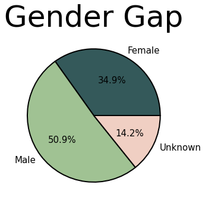

```python
mylabels = ["Female", "Male", "Unknown"]
mycolors = ["#34595a", "#a0c293", "#f0cfc3"]

#controls default text size
plt.rc('font', size=15)

#set title font to size 50
plt.rc('axes', titlesize=50)

plt.pie(total,
        labels = mylabels,
        autopct ='%1.1f%%',
        colors = mycolors,
        wedgeprops = {"edgecolor" : "black",
                      'linewidth': 2,
                      'antialiased': True})
#plt.legend(loc='upper left')
plt.title('Gender Gap')

# Save figure
plt.savefig('/Users/nat/Desktop/gender-gap.png', dpi = 100)

# Display the graph onto the screen
plt.show()
```